# R Notebook sandbox: Playing with Exploratory Factor Analysis (EFA)

## 3.4 Analysis with chosen factors (let’s say 5)

```r
round( psych::describe(Xs), digits=5);
```

|  | vars | n | mean | sd | median | trimmed | mad | min | max | range | skew | kurtosis | se |
| --- | --- | --- | --- | --- | --- | --- | --- | --- | --- | --- | --- | --- | --- |
| V01 | 1 | 678 | 0 | 1 | -0.01740 | 0.02886 | 1.16594 | -2.37665 | 1.55544 | 3.93209 | -0.22214 | -0.58145 | 0.0384 |
| V02 | 2 | 678 | 0 | 1 | -0.16606 | 0.06541 | 1.09818 | -2.38820 | 1.31537 | 3.70357 | -0.38934 | -0.69275 | 0.0384 |
| V03 | 3 | 678 | 0 | 1 | 0.14120 | -0.06030 | 1.08346 | -1.32037 | 2.33355 | 3.65391 | 0.40909 | -0.75483 | 0.0384 |
| V04 | 4 | 678 | 0 | 1 | 0.18241 | 0.11404 | 1.37868 | -3.53720 | 1.11232 | 4.64952 | -0.77937 | 0.31258 | 0.0384 |
| V05 | 5 | 678 | 0 | 1 | 0.03246 | 0.10760 | 1.55383 | -4.15973 | 1.08051 | 5.24024 | -1.02843 | 1.43875 | 0.0384 |
| V06 | 6 | 678 | 0 | 1 | 0.40193 | 0.07780 | 1.25084 | -2.97278 | 1.24561 | 4.21838 | -0.57957 | -0.13651 | 0.0384 |
| V07 | 7 | 678 | 0 | 1 | 0.35403 | 0.07682 | 1.32294 | -3.21521 | 1.24634 | 4.46154 | -0.62308 | 0.03840 | 0.0384 |
| V08 | 8 | 678 | 0 | 1 | 0.24047 | 0.01757 | 1.21468 | -2.21740 | 1.87905 | 4.09644 | -0.13769 | -0.46060 | 0.0384 |
| V09 | 9 | 678 | 0 | 1 | -0.16907 | 0.12382 | 1.69945 | -4.75413 | 0.97720 | 5.73132 | -1.18214 | 2.06304 | 0.0384 |
| V10 | 10 | 678 | 0 | 1 | 0.39877 | 0.08096 | 1.36343 | -3.27972 | 1.31840 | 4.59812 | -0.74486 | 0.54720 | 0.0384 |

[output cut: 50 more lines]

```r
Xs.factanal.5 = factanal(Xs, factors=5, rotation='none');
    # this uses "mle" method ...
    # ## rotation## #
    # varimax = assumes data is independent
    # promax = does a transform
    # none = nothing
# Xs.factanal.5 = factanal(covmat=Xs.corr, n.obs=nrow(Xs), factors=5, rotation='varimax');


# Uniqueness
head(Xs.factanal.5$uniquenesses);
```

```
##       V01       V02       V03       V04       V05       V06
## 0.6868042 0.4506084 0.6030061 0.7272787 0.5076128 0.5700217
```

```r
# "Uniqueness" shows what???


# Map of Variables to Factors (Loadings)
print(Xs.factanal.5$loadings, digits=2, cutoff=0.25, sort=FALSE);
```

```
##
## Loadings:
##     Factor1 Factor2 Factor3 Factor4 Factor5
## V01  0.41           -0.34
## V02  0.48           -0.43   -0.30
## V03                  0.42            0.28
## V04  0.41                    0.29
## V05  0.53   -0.35
## V06  0.39   -0.37                    0.35
## V07  0.33
## V08  0.26
## V09  0.59   -0.30
## V10  0.56           -0.32
## V11          0.58                    0.35
## V12  0.42    0.37   -0.26
## V13  0.43    0.48
## V14  0.59           -0.48
## V15  0.46
## V16  0.64   -0.34
## V17  0.58   -0.38                    0.30
## V18  0.53
## V19  0.49    0.32
## V20          0.36
## V21          0.64
## V22  0.45
## V23  0.55   -0.31
## V24  0.26
## V25          0.29           -0.26    0.36
## V26  0.52                    0.33
## V27  0.40           -0.26
## V28  0.29   -0.30            0.46
## V29          0.56                    0.32
## V30  0.47   -0.33
## V31  0.47    0.38
## V32  0.45
## V33  0.49   -0.28
## V34  0.60    0.32
## V35                  0.33
## V36  0.61
## V37          0.62
```

[output cut: 13 more lines]

```
## V51  0.52    0.25
## V52  0.52
## V53  0.64   -0.36           -0.25
## V54  0.67
## V55  0.33
## V56  0.56
## V57  0.64
## V58  0.61
## V59  0.48    0.46
## V60  0.52   -0.41
##
##                Factor1 Factor2 Factor3 Factor4 Factor5
## SS loadings      13.62    5.49    2.44    1.72    1.44
## Proportion Var    0.23    0.09    0.04    0.03    0.02
## Cumulative Var    0.23    0.32    0.36    0.39    0.41
```

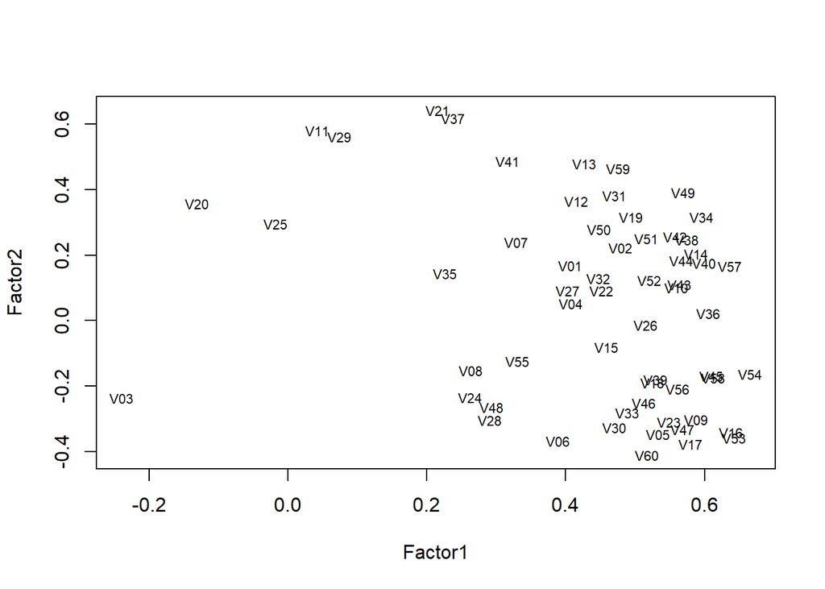

```r
plot(Xs.factanal.5$loadings[,1:2], type="n");
text(Xs.factanal.5$loadings[,1:2],labels=names(Xs),cex=.7) # add variable names
```

```r
print("Cool 3D graphs start here");
```

```
## [1] "Cool 3D graphs start here"
```

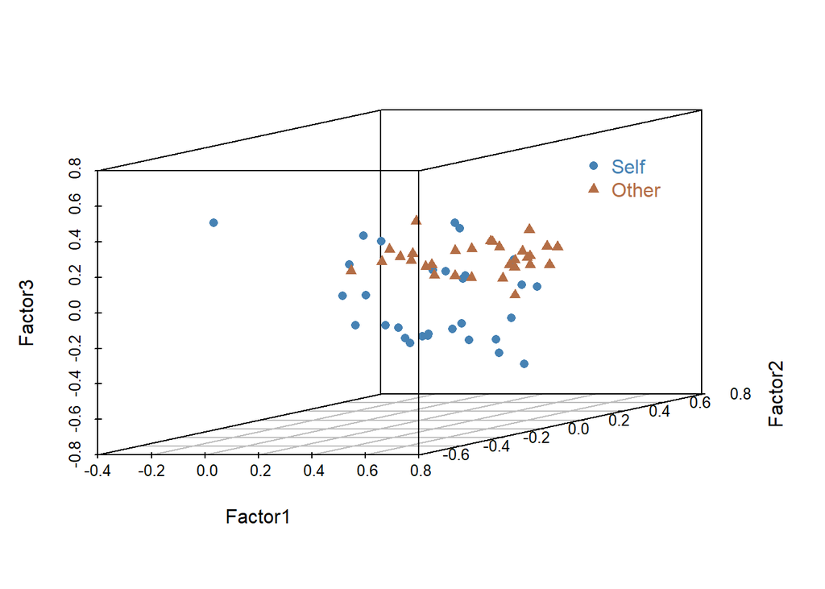

```r
library(scatterplot3d); # install.packages("scatterplot3d", dependencies=TRUE);
library(rgl); # install.packages("rgl", dependencies=TRUE);





pchs = numeric(ncol(Xs));
  pchs[1:30] = 16;  # self
  pchs[31:60] = 17;  # other

# https://www.sessions.edu/color-calculator/
c.choices = c("steelblue", "#b46e46");
colors = character(ncol(Xs));
  colors[1:30] = c.choices[1];  # self
  colors[31:60] = c.choices[2];  # other


Xs.sp3d = scatterplot3d(Xs.factanal.5$loadings[,1:3],
              pch=pchs, color=colors,
              grid=TRUE, box=TRUE,
              type="p",
              angle=22
                );
legend(Xs.sp3d$xyz.convert(1.5, -0.75, 1),
        legend = c("Self","Other"),
        col =  c.choices,
        text.col = c.choices,
        pch = 16:17,
        bty = 'n'
      );
```

```r
# radius
rs = numeric(ncol(Xs));
  rs[1:30] = 0.05;  # self
  rs[31:60] = 0.03;  # other


# http://www.sthda.com/english/wiki/a-complete-guide-to-3d-visualization-device-system-in-r-r-software-and-data-visualization#basic-graph

print("Uncomment here to get more 3D in dynamic interactive form [WILL NOT KNIT]");
```

```
## [1] "Uncomment here to get more 3D in dynamic interactive form [WILL NOT KNIT]"
```

```r
### uncomment, it will not KNIT
# rgl.open(); ## Open a new RGL device
# rgl.bg(color = "white");
# rgl.spheres(Xs.factanal.5$loadings[,1:3],
#             r = rs,
#             color = colors
#             );
### right click on a sphere
# identify3d(Xs.factanal.5$loadings[,1:3], labels = names(Xs), n = 5);


### alternatively
## uncomment, it will not KNIT
# plot3d(Xs.factanal.5$loadings[,1:3],
#         col=colors, box = FALSE,
#         type ="s", radius = rs
#       );






## TODO ... create a movie and store in directory ... create a PNG ...





## how about the raw data ...

round( psych::describe(X), digits=5);
```

|  | vars | n | mean | sd | median | trimmed | mad | min | max | range | skew | kurtosis | se |
| --- | --- | --- | --- | --- | --- | --- | --- | --- | --- | --- | --- | --- | --- |
| V01 | 1 | 678 | 3.41770 | 1.01727 | 3.4 | 3.44706 | 1.18608 | 1 | 5 | 4 | -0.22214 | -0.58145 | 0.03907 |
| V02 | 2 | 678 | 3.57935 | 1.08004 | 3.4 | 3.65000 | 1.18608 | 1 | 5 | 4 | -0.38934 | -0.69275 | 0.04148 |
| V03 | 3 | 678 | 2.44543 | 1.09472 | 2.6 | 2.37941 | 1.18608 | 1 | 5 | 4 | 0.40909 | -0.75483 | 0.04204 |
| V04 | 4 | 678 | 4.04307 | 0.86030 | 4.2 | 4.14118 | 1.18608 | 1 | 5 | 4 | -0.77937 | 0.31258 | 0.03304 |
| V05 | 5 | 678 | 4.17522 | 0.76332 | 4.2 | 4.25735 | 1.18608 | 1 | 5 | 4 | -1.02843 | 1.43875 | 0.02932 |
| V06 | 6 | 678 | 3.81888 | 0.94823 | 4.2 | 3.89265 | 1.18608 | 1 | 5 | 4 | -0.57957 | -0.13651 | 0.03642 |
| V07 | 7 | 678 | 3.88260 | 0.89655 | 4.2 | 3.95147 | 1.18608 | 1 | 5 | 4 | -0.62308 | 0.03840 | 0.03443 |
| V08 | 8 | 678 | 3.16519 | 0.97646 | 3.4 | 3.18235 | 1.18608 | 1 | 5 | 4 | -0.13769 | -0.46060 | 0.03750 |
| V09 | 9 | 678 | 4.31799 | 0.69792 | 4.2 | 4.40441 | 1.18608 | 1 | 5 | 4 | -1.18214 | 2.06304 | 0.02680 |
| V10 | 10 | 678 | 3.85310 | 0.86992 | 4.2 | 3.92353 | 1.18608 | 1 | 5 | 4 | -0.74486 | 0.54720 | 0.03341 |

[output cut: 50 more lines]

```r
X.factanal.5 = factanal(X, factors=5, rotation='none');
head(X.factanal.5$uniquenesses);
```

```
##       V01       V02       V03       V04       V05       V06
## 0.6868042 0.4506084 0.6030061 0.7272787 0.5076128 0.5700217
```

```r
print(X.factanal.5$loadings, digits=2, cutoff=0.25, sort=FALSE);
```

```
##
## Loadings:
##     Factor1 Factor2 Factor3 Factor4 Factor5
## V01  0.41           -0.34
## V02  0.48           -0.43   -0.30
## V03                  0.42            0.28
## V04  0.41                    0.29
## V05  0.53   -0.35
## V06  0.39   -0.37                    0.35
## V07  0.33
## V08  0.26
## V09  0.59   -0.30
## V10  0.56           -0.32
## V11          0.58                    0.35
## V12  0.42    0.37   -0.26
## V13  0.43    0.48
## V14  0.59           -0.48
## V15  0.46
## V16  0.64   -0.34
## V17  0.58   -0.38                    0.30
## V18  0.53
## V19  0.49    0.32
## V20          0.36
## V21          0.64
## V22  0.45
## V23  0.55   -0.31
## V24  0.26
## V25          0.29           -0.26    0.36
## V26  0.52                    0.33
## V27  0.40           -0.26
## V28  0.29   -0.30            0.46
## V29          0.56                    0.32
## V30  0.47   -0.33
## V31  0.47    0.38
## V32  0.45
## V33  0.49   -0.28
## V34  0.60    0.32
## V35                  0.33
## V36  0.61
## V37          0.62
```

[output cut: 13 more lines]

```
## V51  0.52    0.25
## V52  0.52
## V53  0.64   -0.36           -0.25
## V54  0.67
## V55  0.33
## V56  0.56
## V57  0.64
## V58  0.61
## V59  0.48    0.46
## V60  0.52   -0.41
##
##                Factor1 Factor2 Factor3 Factor4 Factor5
## SS loadings      13.62    5.49    2.44    1.72    1.44
## Proportion Var    0.23    0.09    0.04    0.03    0.02
## Cumulative Var    0.23    0.32    0.36    0.39    0.41
```

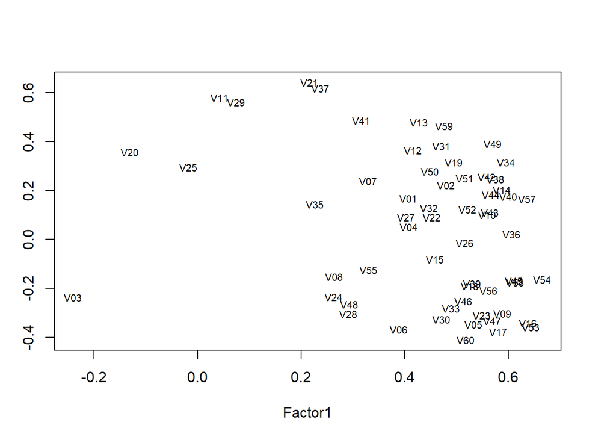

```r
plot(X.factanal.5$loadings[,1:2], type="n");
text(X.factanal.5$loadings[,1:2],labels=names(X),cex=.7) # add variable names
```

```r
## notice any significant differences?  why or why not?  will this always be the case?  why is it the case in this situation?
```

# 4 Personality

The above was to help you understand the key aspects of EFA. Now we want to actually apply it `correctly` based on the data constraints we know. Normally, I would take the Factor Loadings and try to understand them in relationship to the feature (V01).

The loadings can be interpreted as correlations, so if the feature was “Happy” and it’s value for Factor01 was 0.738, that means “Happy” is part of Factor01. If the same feature was also linked to Factor04 with a value of -0.35, I could conclude that “Not Happy” is part of Factor04. (**See* `MonteShaffer_Stats519_HW5.pdf` Problems 2 and 3.)

The Personality data has two sections:

- Natural Self (Questions 1-30): How do you FEEL YOU REALLY ARE?
- Environmental Forces (Questions 31-60): How do you FEEL OTHERS EXPECT YOU TO ACT?

We need to do EFA on these two groups of features: SELF (1-30) and OTHER (31-60)

## 4.1 Optional FREE test

This summer I updated the old test (which is the data we are analyzing). A beta-site of this new adminstration of the test can be found here: http://mpt.mshaffer.com/

If interested, you can take the test for FREE and see some of the business-propositions I am developing as well. The payment processing piece (BUY NOW with a CREDIT CARD) is not complete, and I hope to finish that over the Winter holiday.

You can take it, and you can invite your family and friends to take it. All I would ask is that you have your family/friends use your WSU email (e.g., `YOURNAME@wsu.edu`) even though they should select their own gender, name, and age. If they do (use your email), when the test is complete, you will receive an email with their results.

Below is some example links. The `email` and `p-code` would change for your report. This is my latest report.

- Initial (partial report): http://mpt.mshaffer.com/report/mshaffer@mshaffer.com/p-5f7d9a7fedd5f/
- Initial (partial report with exploding time offer): http://mpt.mshaffer.com/report/mshaffer@mshaffer.com/p-5f7d9a7fedd5f/?has-paid=33
- Full Report (as-if you paid): http://mpt.mshaffer.com/report/mshaffer@mshaffer.com/p-5f7d9a7fedd5f/?has-paid=true

As you can see from the above, I just took the test and spent less than 4 minutes on it. So the accuracy is probably not perfect, but it is somewhat accurate. I would suggest you take the test when you are in a “reflective mood” and devote at least 15 minutes to it.

I would say my natural self is a D-4 or D-6. This is a version of an older report from 2018 http://www.mshaffer.com/arizona/Monte_Shaffer__RleeFtjanggAAOn6m00.pdf, that was true at the time (I was working with a lot of young CS interns/hires working on an ECE project https://nsf.gov/awardsearch/showAward?AWD_ID=1819997 to develop technologies to automate exercise routines for persons with Parkinson’s Disease).

## 4.2 Self: (1-30)

The objective is to assess how many factors to extra for the data. Once determined, a summary of the factors and their relationship to the original words on the personality test.

```r
Xs.self = Xs[,1:30];

Xs.self;
```

[output not shown]

[output cut: 668 more lines]

## 4.3 Other: (31-60)

```r
Xs.other = Xs[,31:60];

Xs.other;
```

[output not shown]

[output cut: 668 more lines]